# Basic Inferential Data Analysis

**Description:** The response is the length of odontoblasts (cells responsible for tooth growth) in 60 guinea pigs. Each animal received one of three dose levels of vitamin C (0.5, 1, and 2 mg/day) by one of two delivery methods, orange juice or ascorbic acid (a form of vitamin C and coded as VC).

**Format:** A data frame with 60 observations on 3 variables.

1. len numeric Tooth length
2. supp factor Supplement type (VC or OJ)
3. dose numeric Dose in milligrams/day

```r
library(ggplot2)
head(ToothGrowth, 5)
```

```
##    len supp dose
## 1  4.2   VC  0.5
## 2 11.5   VC  0.5
## 3  7.3   VC  0.5
## 4  5.8   VC  0.5
## 5  6.4   VC  0.5
```

### Basic summary of the data

```r
str(ToothGrowth)
```

```
## 'data.frame':    60 obs. of  3 variables:
##  $ len : num  4.2 11.5 7.3 5.8 6.4 10 11.2 11.2 5.2 7 ...
##  $ supp: Factor w/ 2 levels "OJ","VC": 2 2 2 2 2 2 2 2 2 2 ...
##  $ dose: num  0.5 0.5 0.5 0.5 0.5 0.5 0.5 0.5 0.5 0.5 ...
```

```r
ToothGrowth$dose <- as.factor(ToothGrowth$dose)
summary(ToothGrowth)
```

```
##       len        supp     dose
##  Min.   : 4.20   OJ:30   0.5:20
##  1st Qu.:13.07   VC:30   1  :20
##  Median :19.25           2  :20
##  Mean   :18.81
##  3rd Qu.:25.27
##  Max.   :33.90
```

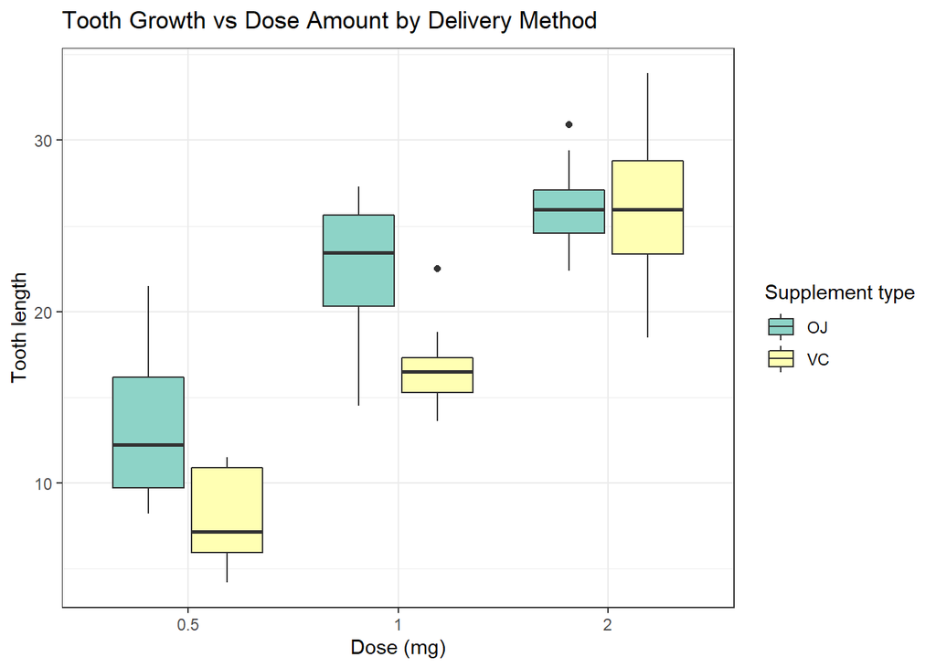

```r
ggplot(data = ToothGrowth, aes(x = as.factor(dose), y = len, fill = supp)) +
  geom_boxplot() +
  xlab("Dose (mg)") +
  ylab("Tooth length") +
  guides(fill = guide_legend(title = "Supplement type")) +
  theme_bw() +
  labs(title=expression("Tooth Growth vs Dose Amount by Delivery Method")) +
  scale_fill_brewer(palette = "Set3")
```

As we can see in the chart above for both supplements tooth length tends to be greater if the dose is larger. On the other hand, supplement OJ tends to give greater tooth length with smaller doses than VC. However when the doses is increased to 2 mg, the second supplement seems to be slightly effective.

```r
t.test(len ~ supp, data = ToothGrowth)
```

```
##
##  Welch Two Sample t-test
##
## data:  len by supp
## t = 1.9153, df = 55.309, p-value = 0.06063
## alternative hypothesis: true difference in means is not equal to 0
## 95 percent confidence interval:
##  -0.1710156  7.5710156
## sample estimates:
## mean in group OJ mean in group VC
##         20.66333         16.96333
```

The p-value 0.06 indicates that we cannot reject the null hypothesis that the different supplement types have no effect on tooth length.

```r
TG_dose_5_2 <- subset (ToothGrowth, dose %in% c(0.5, 2.0))
t.test(len ~ dose, data = TG_dose_5_2)
```

```
##
##  Welch Two Sample t-test
##
## data:  len by dose
## t = -11.799, df = 36.883, p-value = 4.398e-14
## alternative hypothesis: true difference in means is not equal to 0
## 95 percent confidence interval:
##  -18.15617 -12.83383
## sample estimates:
## mean in group 0.5   mean in group 2
##            10.605            26.100
```

```r
TG_dose_1_2 <- subset (ToothGrowth, dose %in% c(1.0, 2.0))
t.test(len ~ dose, data = TG_dose_1_2)
```

```
##
##  Welch Two Sample t-test
##
## data:  len by dose
## t = -4.9005, df = 37.101, p-value = 1.906e-05
## alternative hypothesis: true difference in means is not equal to 0
## 95 percent confidence interval:
##  -8.996481 -3.733519
## sample estimates:
## mean in group 1 mean in group 2
##          19.735          26.100
```

Comparing the 2 highest doses the p-value is also less than 0.05. So like the first case, we can reject the null hypothesis and be sure that increasing doses will lead to greater tooth lengths.

## Conclusions

1. The boxplot showed that supplement type has a slight effect on tooth growth.
2. Higher doses lead an increment in tooth lengths.